# Part A. Processing and visualizing Twitter data

Load all packages here:

```r
library(maps)
library(countrycode)
library(tidyverse)
```

1. The file `tweets.csv` contains around 100,000 geo-located tweets (each row is one tweet but the data does not contain the tweet texts) from 2020 and their automatically detected languages. Read the file into R and add country names derived from the geo-coordinates with the function `map.where()` from the `maps` package. Note that this function might return some outcomes like “country:region”. Therefore, in these cases delete everything from the “:” onwards with a regular expression to only keep the country name. Next, using this newly created country name column and the `countrycode` package, also add a column with ISO-2 country codes (iso2c). You might need to add some country codes manually where associated country names are not recognized by iso2c. In the end, your data frame/tibble should have the columns latitude, longitude, language, country, and country code. (6 points)

```r
# load data
tweets <- read.csv("tweets.csv")

# add column stating country names using coord. using map.where()
tweets$country <- map.where("world", x = tweets$longitude, y = tweets$latitude)

# clean data: regex to delete everything after : in country:region
tweets$country <- gsub(":.*","", tweets$country)

# add ISO-2 country codes with countrycode function
tweets$country_code <- countrycode(tweets$country, origin = 'country.name', destination = 'iso2c')
# error message for Kosovo
# add manually
tweets$country_code[tweets$country == "Kosovo"] <- "XK"
```

2. Now examine the language data. How many unique languages did you find? Can you see which language code corresponds to tweets whose languages could not be predicted? **Delete the tweets/rows with undetermined language.** Which are the most popular languages? (4 points)

```r
# find unique languages
unique_languages <- unique(sort(tweets$language))

# number of unique languages
print(paste("There are", length(unique_languages), "unique languages"))
```

```
## [1] "There are 51 unique languages"
```

```r
# which ones are undetermined? the ones that have the 'und' code
# next, delete them
tweets <- tweets[!c(tweets$language == "und"),]

# most popular languages? - rank them
most_popular <- tweets %>%
  group_by(language) %>%
  summarise(n = n()) %>%
  arrange(desc(n))

# This shows how English is the most popular language followed by Spanish, Turkish and French. After French the language users drop below 4K. We can observe this below:
most_popular[1:5,]
```

```
## # A tibble: 5 × 2
##   language     n
##   <chr>    <int>
## 1 en       36685
## 2 es       11475
## 3 tr       10152
## 4 fr        7050
## 5 it        3941
```

3. Produce a map which displays the tweets with their location and also the language distribution by country. Have a look at Pablo Barberá’s [Twitter profile](https://twitter.com/p_barbera) for a clue how this map could look like with color representing languages. (11 points)

Hint: The map code from the streaming API examples can be a starting point here.

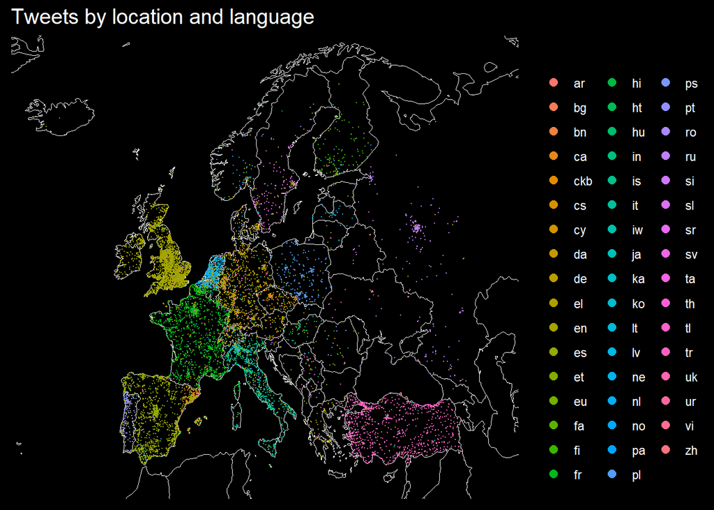

```r
# mapping
map.data <- map_data("world")

ggplot(map.data) +
  geom_map(aes(map_id = region),
           map = map.data,
           fill = "black",
           color = "white",
           size = 0.25) +
  expand_limits(x = map.data$long, y = map.data$lat) +
# Limits for x and y axis
  scale_x_continuous(limits=c(-23, 50)) +
  scale_y_continuous(limits = c(35, 70)) +
# Adding the dot for each tweet and specifying dot size, transparency, and colour
  geom_point(data = tweets,
             aes(x = longitude, y = latitude, colour = language),
             size = 0.00001,
             alpha = 1) +
  ggtitle("Tweets by location and language") +
  theme_minimal() +
# Removing unnecessary graph elements
  theme(plot.title= element_text(size=15,
                                   color="white"),
        axis.text = element_blank(),
          axis.ticks = element_blank(),
        axis.title = element_blank(),
        panel.background = element_rect(fill = 'black'),
        panel.border = element_blank(),
        panel.grid.major = element_blank(),
        panel.grid.minor = element_blank(),
        plot.background = element_rect(fill = 'black'),
        legend.text = element_text(color = 'white')) +
# edit size of legend dots
  guides(colour = guide_legend(override.aes = list(size = 2.5)))
```

4. Create a data frame with only four variables: `country`, `country_code`, `language`, and `n_tweets`, i.e. the number of tweets for each combination of country and language. To make it smaller, you can keep only the rows for which `n_tweets` is greater than 0! Save this data frame into a file called `part_a_country_language_distribution.csv` – we will work with it in Part B. Which countries produced the most and the least tweets? (2 points)

```r
# data frame: country, country_code, language, n_tweets
to_make_new_csv <- tweets %>%
  group_by(country, country_code, language) %>%
  summarise(n_tweets = n())
# save as csv
write.csv(to_make_new_csv,"part_a_country_language_distribution.csv", row.names = FALSE)
```